# 一次産品の価格推移

山本雅資

2024-07-15

# 1 Basic Settings

```r
library(ggmap)
library(maps)
library(tidyverse)
library(readxl)
library(ggrepel)
library(ggthemes)
library(lubridate)
library(MetBrewer) #https://qiita.com/ocean_f/items/ab86eac9550607ec5e0e
```

# 2 IMF Primary Commodity Prices

IMF Primary Commodity Pricesは[ここ](https://www.imf.org/en/Research/commodity-prices)でゲットできる。

```r
setwd("/Users/yamamoto/R/IMF")

# 管理しやすい変数名を作成
vnames<-c("yearmonth",paste0("VAR",1:94,sep=""))

# 読み込みと同時に変数名を変更
DB<-read_excel("external-dataJune2024.xlsx",skip=4,col_names = vnames)

# 時系列
DB$date= seq(as.Date("1990-01-01"),
          length=412,#lengthで期間指定、
          by="months") #byで単位指定
```

## 2.1 砂糖

メインの指標

This is about `*Sugar, Free Market, Coffee Sugar and Cocoa Exchange (CSCE) contract no.11 nearest future position, US cents per pound*’

According to [ICE](https://www.ice.com/products/23/Sugar-No-11-Futures), the Sugar No. 11 contract is the world benchmark contract for raw sugar trading. The contract prices the physical delivery of raw cane sugar, free-on-board the receiver’s vessel to a port within the country of origin of the sugar.

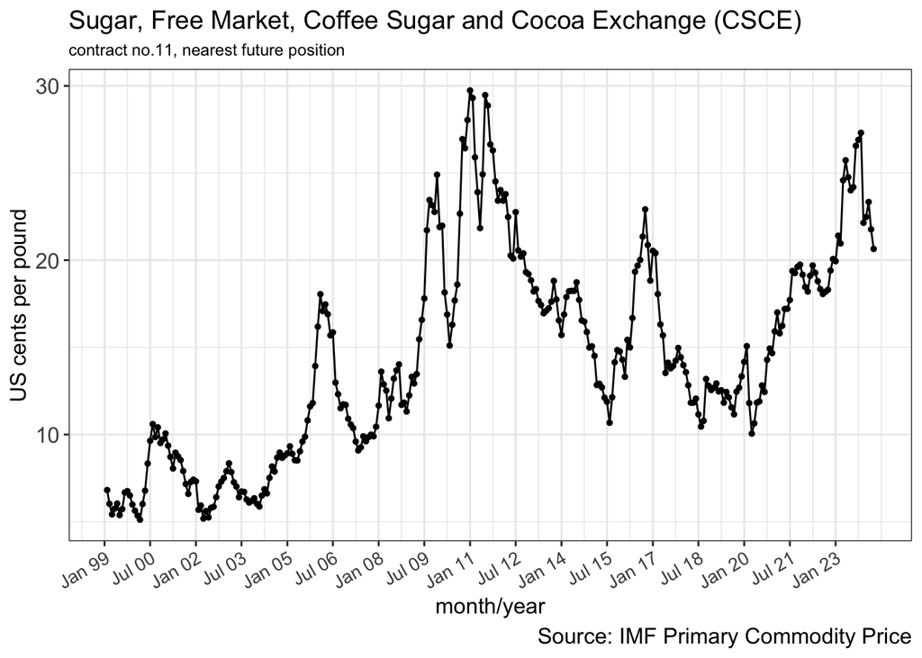

```r
# First thing is to change your working directory
setwd("/users/yamamoto/R/IMF/")

# Sugar, Free Market, Coffee Sugar and Cocoa Exchange (CSCE) contract no.11
# nearest future position, US cents per pound
# VAR62 (BK列)

# Dateクラスのベクトルを使って目盛位置を指定する。byで間隔の指定もできる。
datebreaksSG1 <- seq(as.Date("1999-01-01"), as.Date("2024-04-01"),
                  by="18 month")

DB |>
  filter(date>"1999-01-01") |>
  ggplot()+
  geom_point(aes(x=date,y=VAR62),size=1)+
  geom_line(aes(x=date,y=VAR62))+
  xlab("month/year")+
  ylab("US cents per pound")+
  theme_bw()+
  labs(title="Sugar, Free Market, Coffee Sugar and Cocoa Exchange (CSCE)" ,
       subtitle="contract no.11, nearest future position",
       caption="Source: IMF Primary Commodity Price")+
  theme(plot.title    = element_text(size=14),
        plot.subtitle    = element_text(size=9),
    axis.title.x = element_text(size=12),
        axis.text.x = element_text(size=10,angle=30, hjust=1),
      axis.title.y = element_text(size=12),
      axis.text.y = element_text(size=12),
      legend.text = element_text(size=12),
      legend.title = element_text(size=12),
      plot.caption  = element_text(size=12)
      )+
  scale_x_date(breaks=datebreaksSG1,date_labels = "%b %y")+
  guides(size=none)->SG1

SG1
```

```r
#保存
ggsave(filename = "SG2024april.pdf",plot=SG1,width=5, height=8,units="in")
```

USの輸入価格

*Sugar, U.S. import price, contract no.14 nearest futures position, US cents per pound (Footnote: No. 14 revised to No. 16)*

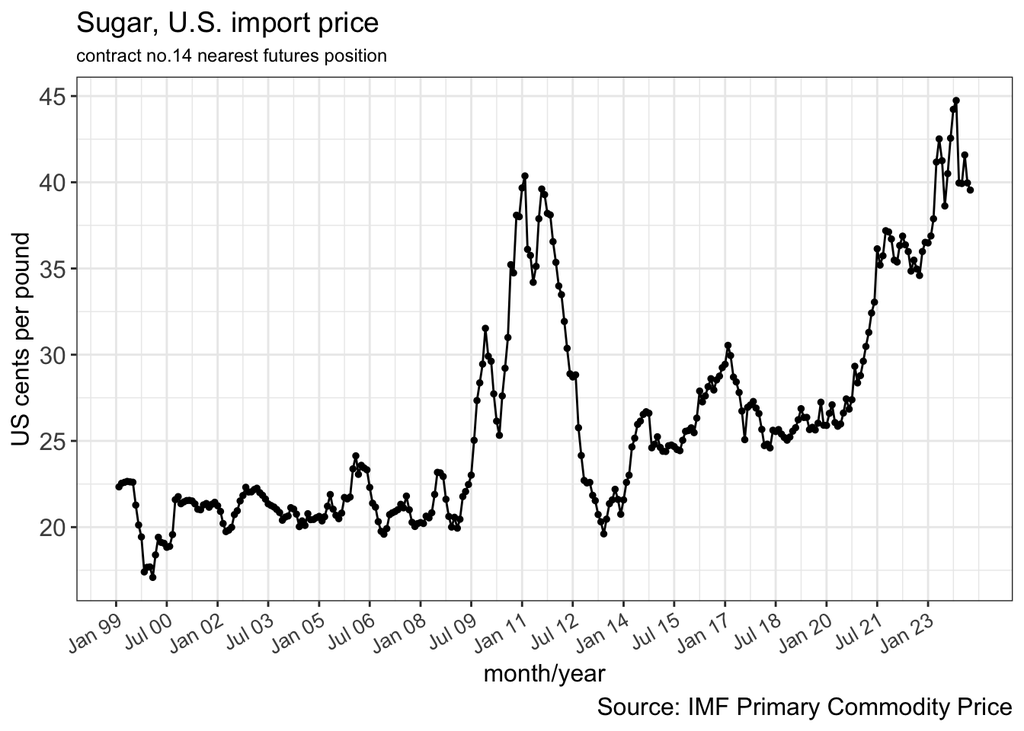

```r
# First thing is to change your working directory
setwd("/users/yamamoto/R/IMF/")

# Sugar, U.S. import price, contract no.14 nearest futures position,
# US cents per pound (Footnote: No. 14 revised to No. 16)
# VAR63 (BL列)

# Dateクラスのベクトルを使って目盛位置を指定する。byで間隔の指定もできる。
datebreaksSG1 <- seq(as.Date("1999-01-01"), as.Date("2024-04-01"),
                  by="18 month")

DB |>
  filter(date>"1999-01-01") |>
  ggplot()+
  geom_point(aes(x=date,y=VAR63),size=1)+
  geom_line(aes(x=date,y=VAR63))+
  xlab("month/year")+
  ylab("US cents per pound")+
  theme_bw()+
  labs(title="Sugar, U.S. import price" ,
       subtitle="contract no.14 nearest futures position",
       caption="Source: IMF Primary Commodity Price")+
  theme(plot.title    = element_text(size=14),
        plot.subtitle    = element_text(size=9),
    axis.title.x = element_text(size=12),
        axis.text.x = element_text(size=10,angle=30, hjust=1),
      axis.title.y = element_text(size=12),
      axis.text.y = element_text(size=12),
      legend.text = element_text(size=12),
      legend.title = element_text(size=12),
      plot.caption  = element_text(size=12)
      )+
  scale_x_date(breaks=datebreaksSG1,date_labels = "%b %y")+
  guides(size=none)->SG2

SG2
```

```r
ggsave(filename = "SG2024april2.pdf",plot=SG2,width=5, height=8,units="in")
```

砂糖の二つでデータを同じグラフにプロットしてみる。

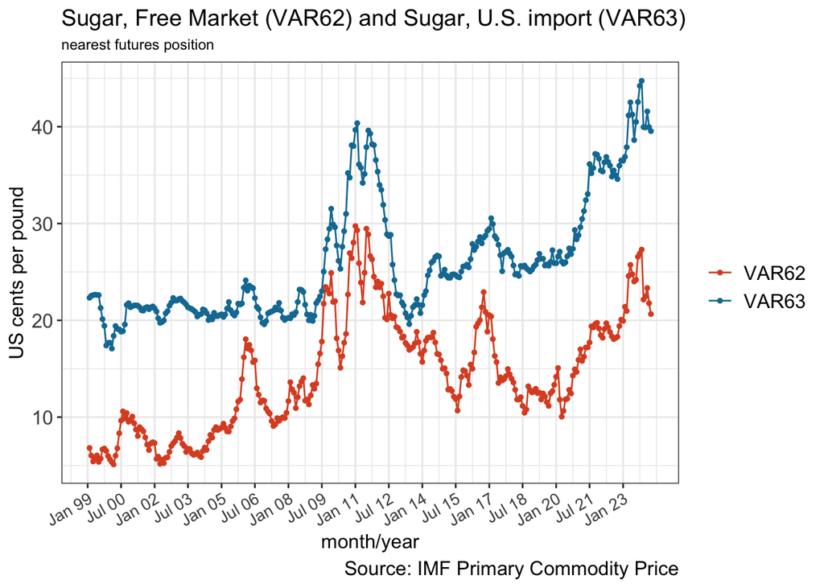

```r
DB |>
  select(date,VAR62,VAR63) |>
  pivot_longer(c(VAR62,VAR63),names_to = "name") |>
  filter(date>"1999-01-01") |>
  ggplot()+
  geom_point(aes(x=date,y=value,color=name),size=1)+
  geom_line(aes(x=date,y=value,color=name))+
  xlab("month/year")+
  ylab("US cents per pound")+
  theme_bw()+
  labs(title="Sugar, Free Market (VAR62) and Sugar, U.S. import (VAR63)" ,
       subtitle="nearest futures position",
       caption="Source: IMF Primary Commodity Price")+
  theme(plot.title    = element_text(size=14),
        plot.subtitle    = element_text(size=9),
    axis.title.x = element_text(size=12),
        axis.text.x = element_text(size=10,angle=30, hjust=1),
      axis.title.y = element_text(size=12),
      axis.text.y = element_text(size=12),
      legend.text = element_text(size=12),
      legend.title = element_text(size=12),
      plot.caption  = element_text(size=12)
      )+
  scale_color_manual(values= met.brewer("Egypt", 2))+
  scale_x_date(breaks=datebreaksSG1,date_labels = "%b %y")+
  labs(color="")+
  guides(size=none)->SG2

SG2
```

## 2.2 エネルギー指数

### 2.2.1 統合的な指標

*Fuel (Energy) Index, 2016 = 100, includes Crude oil (petroleum), Natural Gas, Coal Price and Propane Indices*

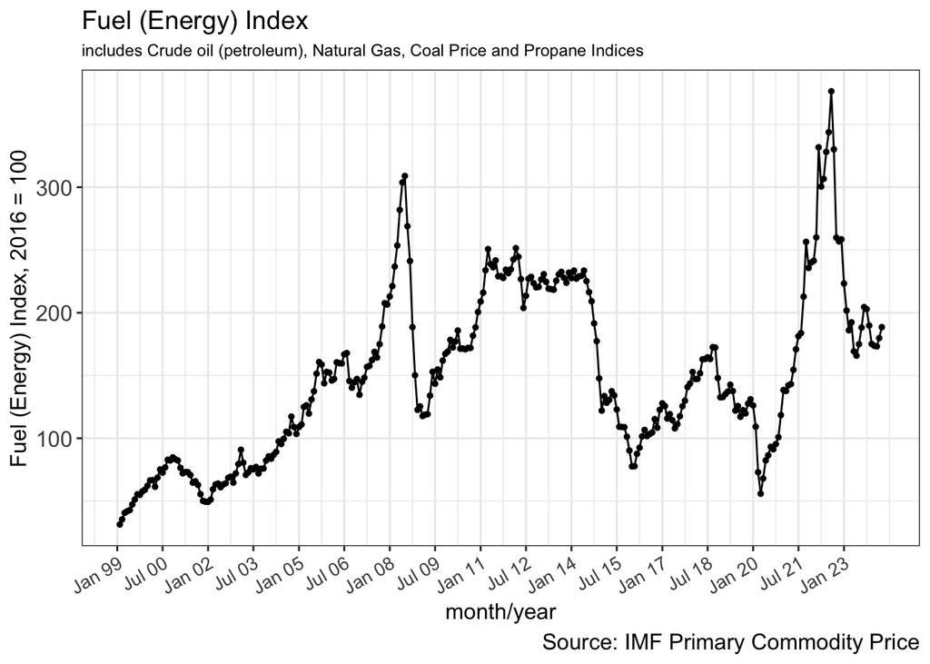

```r
# First thing is to change your working directory
setwd("/users/yamamoto/R/IMF/")

# Fuel (Energy) Index, 2016 = 100, includes Crude oil (petroleum), Natural Gas,
# Coal Price and Propane Indices
# VAR15 (P列)

# Dateクラスのベクトルを使って目盛位置を指定する。byで間隔の指定もできる。
datebreaksSG1 <- seq(as.Date("1999-01-01"), as.Date("2024-04-01"),
                  by="18 month")

DB |>
  filter(date>"1999-01-01") |>
  ggplot()+
  geom_point(aes(x=date,y=VAR15),size=1)+
  geom_line(aes(x=date,y=VAR15))+
  xlab("month/year")+
  ylab("Fuel (Energy) Index, 2016 = 100")+
  theme_bw()+
  labs(title="Fuel (Energy) Index" ,
       subtitle="includes Crude oil (petroleum), Natural Gas, Coal Price and Propane Indices",
       caption="Source: IMF Primary Commodity Price")+
  theme(plot.title    = element_text(size=14),
        plot.subtitle    = element_text(size=9),
    axis.title.x = element_text(size=12),
        axis.text.x = element_text(size=10,angle=30, hjust=1),
      axis.title.y = element_text(size=12),
      axis.text.y = element_text(size=12),
      legend.text = element_text(size=12),
      legend.title = element_text(size=12),
      plot.caption  = element_text(size=12)
      )+
  scale_x_date(breaks=datebreaksSG1,date_labels = "%b %y")+
  guides(size=none)->EnergyIndex1

EnergyIndex1
```

```r
ggsave(filename = "Fuel2024april.pdf",plot=EnergyIndex1,width=5, height=8,units="in")
```

### 2.2.2 原油価格

原油価格の統合的な指標

*Crude Oil (petroleum), Price index, 2016 = 100, simple average of three spot prices; Dated Brent, West Texas Intermediate, and the Dubai Fateh*

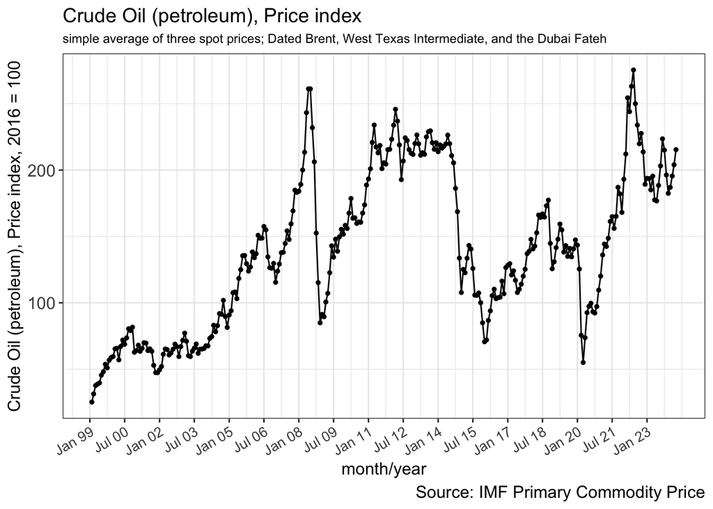

```r
# First thing is to change your working directory
setwd("/users/yamamoto/R/IMF/")

# Crude Oil (petroleum), Price index, 2016 = 100, simple average of three spot
# prices; Dated Brent, West Texas Intermediate, and the Dubai Fateh
# VAR16 (Q列)

# Dateクラスのベクトルを使って目盛位置を指定する。byで間隔の指定もできる。
datebreaksCrudeOil1 <- seq(as.Date("1999-01-01"), as.Date("2024-04-01"),
                  by="18 month")

DB |>
  filter(date>"1999-01-01") |>
  ggplot()+
  geom_point(aes(x=date,y=VAR16),size=1)+
  geom_line(aes(x=date,y=VAR16))+
  xlab("month/year")+
  ylab("Crude Oil (petroleum), Price index, 2016 = 100")+
  theme_bw()+
  labs(title="Crude Oil (petroleum), Price index" ,
       subtitle="simple average of three spot prices; Dated Brent, West Texas Intermediate, and the Dubai Fateh",
       caption="Source: IMF Primary Commodity Price")+
  theme(plot.title    = element_text(size=14),
        plot.subtitle    = element_text(size=9),
    axis.title.x = element_text(size=12),
        axis.text.x = element_text(size=10,angle=30, hjust=1),
      axis.title.y = element_text(size=12),
      axis.text.y = element_text(size=12),
      legend.text = element_text(size=12),
      legend.title = element_text(size=12),
      plot.caption  = element_text(size=12)
      )+
  scale_x_date(breaks=datebreaksCrudeOil1,date_labels = "%b %y")+
  guides(size=none)->CrudeOil1

CrudeOil1
```

```r
ggsave(filename = "CrudeOilindex2024april.pdf",plot=CrudeOil1,width=5, height=8,units="in")
```

### 2.2.3 天然ガス価格

天然ガス価格の統合的な指標

*Natural Gas Price Index, 2016 = 100, includes European, Japanese, and American Natural Gas Price Indices*

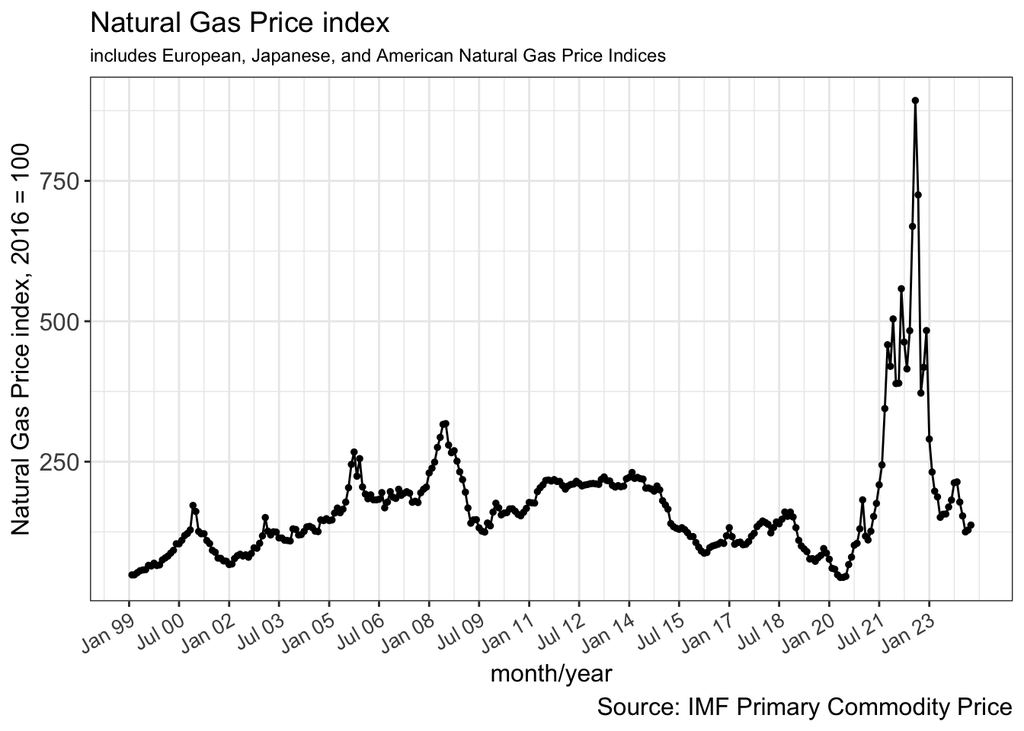

```r
# First thing is to change your working directory
setwd("/users/yamamoto/R/IMF/")

# Natural Gas Price Index, 2016 = 100, includes European, Japanese,
# and American Natural Gas Price Indices
# VAR17 (R列)

# Dateクラスのベクトルを使って目盛位置を指定する。byで間隔の指定もできる。
datebreaksNgas1 <- seq(as.Date("1999-01-01"), as.Date("2024-04-01"),
                  by="18 month")

DB |>
  filter(date>"1999-01-01") |>
  ggplot()+
  geom_point(aes(x=date,y=VAR17),size=1)+
  geom_line(aes(x=date,y=VAR17))+
  xlab("month/year")+
  ylab("Natural Gas Price index, 2016 = 100")+
  theme_bw()+
  labs(title="Natural Gas Price index" ,
       subtitle="includes European, Japanese, and American Natural Gas Price Indices",
       caption="Source: IMF Primary Commodity Price")+
  theme(plot.title    = element_text(size=14),
        plot.subtitle    = element_text(size=9),
    axis.title.x = element_text(size=12),
        axis.text.x = element_text(size=10,angle=30, hjust=1),
      axis.title.y = element_text(size=12),
      axis.text.y = element_text(size=12),
      legend.text = element_text(size=12),
      legend.title = element_text(size=12),
      plot.caption  = element_text(size=12)
      )+
  scale_x_date(breaks=datebreaksNgas1,date_labels = "%b %y")+
  guides(size=none)->Ngas1

Ngas1
```

```r
ggsave(filename = "NgasIndex2024april.pdf",plot=Ngas1,width=5, height=8,units="in")
```

### 2.2.4 石炭価格

石炭価格の統合的な指標

*Coal Price Index, 2016 = 100, includes Australian and South African Coal*

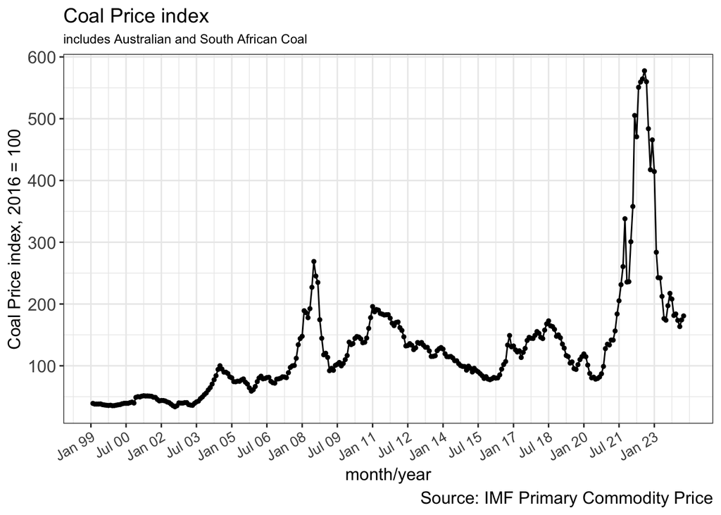

```r
# First thing is to change your working directory
setwd("/users/yamamoto/R/IMF/")

# Coal Price Index, 2016 = 100, includes Australian and South African Coal
# VAR18 (S列)

# Dateクラスのベクトルを使って目盛位置を指定する。byで間隔の指定もできる。
datebreaksCoal1 <- seq(as.Date("1999-01-01"), as.Date("2024-04-01"),
                  by="18 month")

DB |>
  filter(date>"1999-01-01") |>
  ggplot()+
  geom_point(aes(x=date,y=VAR18),size=1)+
  geom_line(aes(x=date,y=VAR18))+
  xlab("month/year")+
  ylab("Coal Price index, 2016 = 100")+
  theme_bw()+
  labs(title="Coal Price index" ,
       subtitle="includes Australian and South African Coal",
       caption="Source: IMF Primary Commodity Price")+
  theme(plot.title    = element_text(size=14),
        plot.subtitle    = element_text(size=9),
    axis.title.x = element_text(size=12),
        axis.text.x = element_text(size=10,angle=30, hjust=1),
      axis.title.y = element_text(size=12),
      axis.text.y = element_text(size=12),
      legend.text = element_text(size=12),
      legend.title = element_text(size=12),
      plot.caption  = element_text(size=12)
      )+
  scale_x_date(breaks=datebreaksCoal1,date_labels = "%b %y")+
  guides(size=none)->Coal1

Coal1
```

```r
ggsave(filename = "CoalIndex2024april.pdf",plot=Coal1,width=5, height=8,units="in")
```

エネルギー系の3つのデータを同じグラフにプロットしてみる。

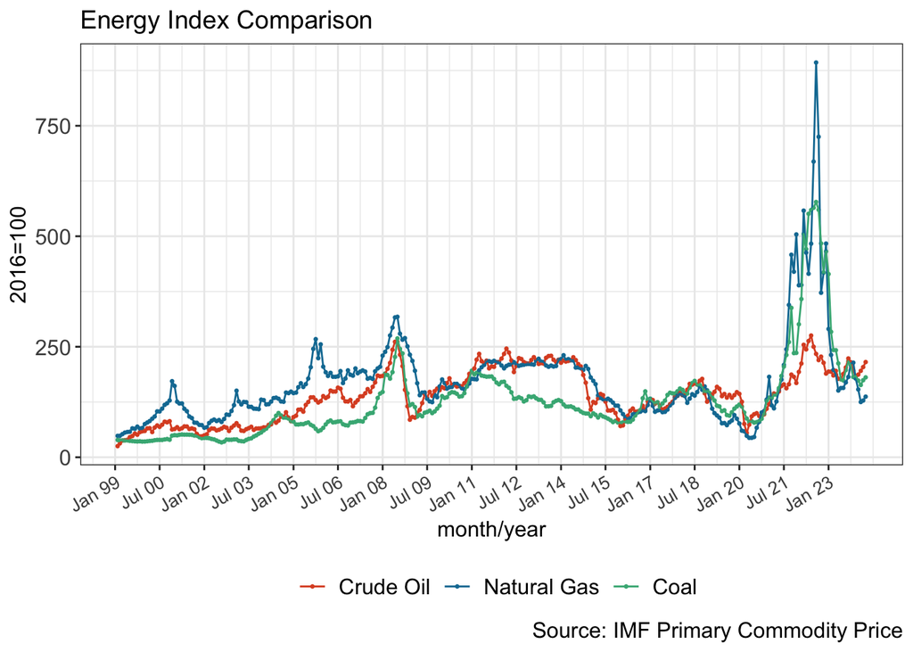

```r
# Dateクラスのベクトルを使って目盛位置を指定する。byで間隔の指定もできる。
datebreaksEC1 <- seq(as.Date("1999-01-01"), as.Date("2024-04-01"),
                  by="18 month")

legend.labels.EC1 <- c("Crude Oil", "Natural Gas", "Coal")

DB |>
  select(date,VAR16,VAR17,VAR18) |>
  pivot_longer(c(VAR16,VAR17,VAR18),names_to = "name") |>
  filter(date>"1999-01-01") |>
  ggplot()+
  geom_point(aes(x=date,y=value,color=name),size=0.5)+
  geom_line(aes(x=date,y=value,color=name))+
  xlab("month/year")+
  ylab("2016=100")+
  theme_bw()+
  labs(title="Energy Index Comparison" ,
       #subtitle="VAR16=Crude Oil, VAR17=Natural Gas, VAR18=Coal",
       caption="Source: IMF Primary Commodity Price")+
  theme(plot.title    = element_text(size=14),
        plot.subtitle    = element_text(size=9),
        axis.title.x = element_text(size=12),
        axis.text.x = element_text(size=10,angle=30, hjust=1),
        axis.title.y = element_text(size=12),
        axis.text.y = element_text(size=12),
        legend.text = element_text(size=12),
        legend.title = element_text(size=12),
        legend.position = "bottom",
        plot.caption  = element_text(size=12)
      )+
  scale_color_manual(values= met.brewer("Egypt", 3),
                     labels = legend.labels.EC1)+
  scale_x_date(breaks=datebreaksEC1 ,date_labels = "%b %y")+
  labs(color="")+
  guides(size=none)->EC1

EC1
```

```r
ggsave(filename = "EC2024april.pdf",plot=EC1,width=8, height=5,units="in")
```

これをみると、ロシアによるウクライナ侵攻の前後で、原油価格は天然ガスや石炭ほどは上昇しなかったことがわかる。

## 2.3 銅価格

*Copper, grade A cathode, LME spot price, CIF European ports, US$ per metric ton*

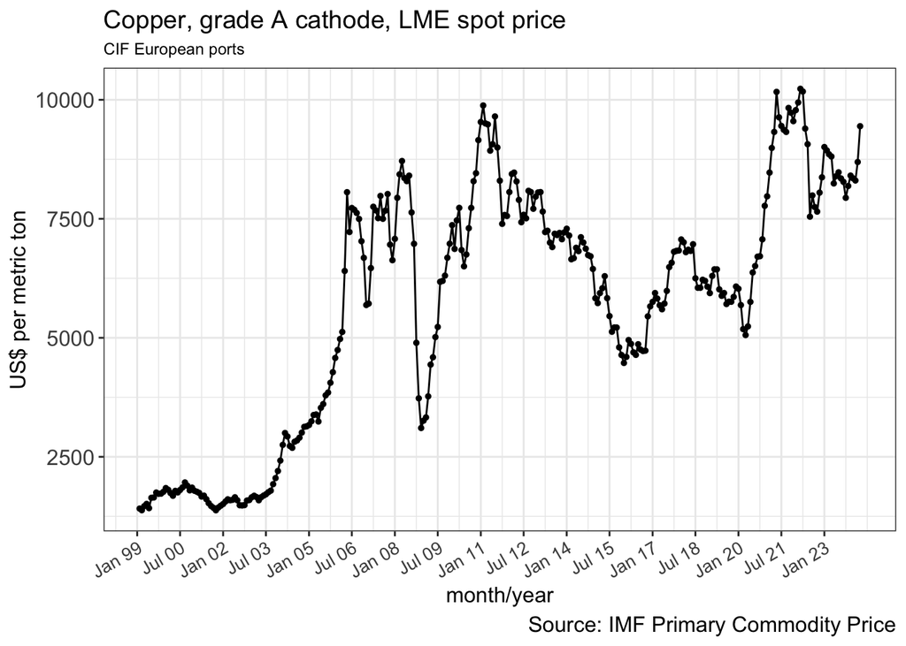

```r
# First thing is to change your working directory
setwd("/users/yamamoto/R/IMF/")

# Copper, grade A cathode, LME spot price, CIF European ports,
# US$ per metric ton,
# VAR29 (AD列)

# Dateクラスのベクトルを使って目盛位置を指定する。byで間隔の指定もできる。
datebreaksCopper1 <- seq(as.Date("1999-01-01"), as.Date("2024-04-01"),
                  by="18 month")

DB |>
  filter(date>"1999-01-01") |>
  ggplot()+
  geom_point(aes(x=date,y=VAR29),size=1)+
  geom_line(aes(x=date,y=VAR29))+
  xlab("month/year")+
  ylab("US$ per metric ton")+
  theme_bw()+
  labs(title="Copper, grade A cathode, LME spot price" ,
       subtitle="CIF European ports",
       caption="Source: IMF Primary Commodity Price")+
  theme(plot.title    = element_text(size=14),
        plot.subtitle    = element_text(size=9),
    axis.title.x = element_text(size=12),
        axis.text.x = element_text(size=10,angle=30, hjust=1),
      axis.title.y = element_text(size=12),
      axis.text.y = element_text(size=12),
      legend.text = element_text(size=12),
      legend.title = element_text(size=12),
      plot.caption  = element_text(size=12)
      )+
  scale_x_date(breaks=datebreaksCopper1,date_labels = "%b %y")+
  guides(size=none)->Copper1

Copper1
```

```r
ggsave(filename = "Copper1.pdf",plot=Copper1,width=8, height=5,units="in")
```